# Generate figures of *Oligo* performance in Simulation Analysis

Ningshan Li

2024/05/30

# 1 Summary

We selected **Oligo** from 12 cell types for evaluating the performance in identifying “rare cell types” in cell type deconvolution. Our analysis is divided into two parts:

1. **Identifying “rare cell types” from spatial spot data**:

   We analyzed the [STARmap-based simulation](https://rawcdn.githack.com/az7jh2/SDePER_Analysis/c60dcb036816bd61b5a8b3752d473a5b591b52b6/Simulation/Generate_simulation_data/generate_simulated_spatial_data.nb.html) results and [high density sequencing-based simulation](https://rawcdn.githack.com/az7jh2/SDePER_Analysis/d22e0c9b4574530a8ecbdf620638f2527ec20c5e/Simulation_seq_based/Generate_high_density_simulation_data/generate_simulated_spatial_data.nb.html) results, focusing on the performance of SDePER on Oligo. This analysis was first stratified by the total number of cells in spots then by the number of Oligo cells in spots to explore how the performance varies as the number of Oligo cells in a spot increases.
2. **Identifying cell types with limited cells in reference scRNA-seq data**:

   We performed analyses using SDePER on [STARmap-based simulated data with downsampled reference datasets](https://rawcdn.githack.com/az7jh2/SDePER_Analysis/5dc5cf8a6d97237304017c260f96ed0d3e41cb51/Simulation/Generate_downsampled_ref_data/generate_downsampled_ref_data.nb.html). Specifically, we randomly downsampled the number of Oligo cells to 5, 10, 20, and 50 in both internal and external reference dataset. We then examined how the performance is affected by the increasing number of Oligo cells in the reference dataset.

By conducting these analyses, we aim to understand the performance variations and limitations in identifying rare cell types under different conditions in spatial and scRNA-seq data.

- **Inputs**:
  - [`simulation_all_results.rds`](https://github.com/az7jh2/SDePER_Analysis/blob/main/Figures/Simulation/simulation_all_results.rds): cell type deconvolution results of all methods, as well as the ground truth in *STARmap-based* simulation analysis.
  - [`simulation_seq_based_high_density_all_results.rds`](https://github.com/az7jh2/SDePER_Analysis/blob/main/Figures/Simulation_seq_based/simulation_seq_based_high_density_all_results.rds): cell type deconvolution results of SDePER and GLRM in *high density sequencing-based* simulation analysis, as well as the ground truth.
  - [`sim_spatial_spot_ncell.csv`](https://github.com/az7jh2/SDePER_Analysis/blob/main/Simulation/Generate_simulation_data/sim_spatial_spot_ncell.csv): number of cells in synthesized spatial spots in *STARmap-based* simulation analysis.
  - [`sim_seq_based_3x_spatial_spot_ncell.csv`](https://github.com/az7jh2/SDePER_Analysis/blob/main/Simulation_seq_based/Generate_high_density_simulation_data/sim_seq_based_3x_spatial_spot_ncell.csv): number of cells in synthesized spatial spots of **3x** setting in *high density sequencing-based* simulation analysis.
  - [`sim_seq_based_6x_spatial_spot_ncell.csv`](https://github.com/az7jh2/SDePER_Analysis/blob/main/Simulation_seq_based/Generate_high_density_simulation_data/sim_seq_based_6x_spatial_spot_ncell.csv): number of cells in synthesized spatial spots of **6x** setting in *high density sequencing-based* simulation analysis.
  - [`simulation_downsampled_ref_all_results.rds`](https://github.com/az7jh2/SDePER_Analysis/blob/main/Figures/Simulation/simulation_downsampled_ref_all_results.rds): cell type deconvolution results on *STARmap-based* simulated data with *downsampled reference*.
- **Outputs**:
  - Figure. Plot of performance of SDePER on *STARmap-based* simulated data stratified by the number of Oligo cells per spot
  - Figure. Plot of performance of SDePER on *high density sequencing-based* simulated data stratified by the number of Oligo cells per spot
  - Figure. Plot of performance of SDePER on *STARmap-based* simulated data with *downsampled reference* stratified by the number of Oligo cells in reference

# 2 Version

```r
version[['version.string']]
```

```
[1] "R version 4.2.2 Patched (2022-11-10 r83330)"
```

```r
print(sprintf('Package %s version: %s', 'ggplot2', packageVersion('ggplot2')))
```

```
[1] "Package ggplot2 version: 3.4.2"
```

```r
print(sprintf('Package %s version: %s', 'ggpubr', packageVersion('ggpubr')))
```

```
[1] "Package ggpubr version: 0.6.0"
```

```r
print(sprintf('Package %s version: %s', 'philentropy', packageVersion('philentropy'))) # JSD function
```

```
[1] "Package philentropy version: 0.7.0"
```

# 3 Define functions

## 3.1 Target cell type

```r
target_ct = 'Oligo'
```

## 3.2 QC function

Check the order of spots and cell types are consistent before performance evaluation.

Check whether negative values of estimated cell type proportions exist, as negative values may cause error in JSD calculation and got `NaN`. Replace them as 0.

```r
qc = function(results) {
  for (scenario in names(results)) {
    if (scenario != 'Truth') {
      for (method_name in names(results[[scenario]])) {
        stopifnot(all(row.names(results[[scenario]][[method_name]]) == row.names(results[['Truth']])))
        stopifnot(all(colnames(results[[scenario]][[method_name]]) == colnames(results[['Truth']])))
      }
    }
  }

  for (scenario in names(results)) {
    if (scenario != 'Truth') {
     for (method_name in names(results[[scenario]])) {
        tmp_df = results[[scenario]][[method_name]]
        for (i in 1:nrow(tmp_df)) {
          for (j in 1:ncol(tmp_df)) {
            if (tmp_df[i, j] < 0) {
              stop(sprintf('%s: %s result: row %d (%s) column %d (%s) has negative value %g', scenario, method_name, i, row.names(tmp_df)[i], j, colnames(tmp_df)[j], tmp_df[i, j]))
            }
          }
        }
      }
    }
  }
}
```

## 3.3 Function to calculate spot-wise performance of Oligo

4 performance measurements:

- root mean square error (**RMSE**) or Absolute Error since only one cell type: quantifies the estimation accuracy of Oligo
- relative absolute error (**RAE**): RMSE divided by the true cell type proportion
- false discovery rate (**FDR**): measures the proportion of spots where Oligo was falsely predicted to be present
- false negative rate (**FNR**): measures the proportion of spots where Oligo was incorrectly classified as absent

```r
calcPerformance = function(truth, pred) {
  # calculate RMSE, FDR and FNR for each row
  # inputs are matrix with rows as spots and columns as cell types, order has been checked to be consistent
  stopifnot(all(row.names(truth) == row.names(pred)))
  stopifnot(all(colnames(truth) == colnames(pred)))
  stopifnot(ncol(truth) == 1)
  stopifnot(ncol(pred) == 1)

  perform_df = data.frame(RMSE=numeric(), RAE=numeric(), Result=character(), stringsAsFactors = F)

  for (i in 1:nrow(truth)) {
    RMSE = abs(truth[i, 1] - pred[i, 1])
    RAE = RMSE / truth[i, 1]
    if (truth[i, 1] > 0 && pred[i, 1] == 0) {
      result = 'FN'
    } else if (truth[i, 1] > 0 && pred[i, 1] > 0) {
      result =  'TP'
    } else if (truth[i, 1] == 0 && pred[i, 1] > 0) {
      result =  'FP'
    } else if (truth[i, 1] == 0 && pred[i, 1] == 0) {
      result = 'TN'
    } else {
      stop('unknown error!')
    }

    perform_df[nrow(perform_df)+1, ] = list(RMSE, RAE, result)
  }

  # also record spot names
  stopifnot(nrow(perform_df) == nrow(truth))
  perform_df['Spot'] = row.names(truth)

  return(perform_df)
}
```

## 3.4 Calculate spot-wise performance

```r
calcPerformanceAllSpots = function(results) {
  performs = list()
  for (scenario in names(results)) {
    if (scenario != 'Truth') {
      performs[[scenario]] = list()
      for (method_name in names(results[[scenario]])) {
        performs[[scenario]][[method_name]] = calcPerformance(as.matrix(results[['Truth']][, target_ct, drop=F]),
                                                              as.matrix(results[[scenario]][[method_name]][, target_ct, drop=F]))
      }
    }
  }
  return(performs)
}
```

## 3.5 Summary spot-wise performance into method-wise

We also calculate performance summary first stratified by the total number of cells in spots then by the number of Oligo cells in spots.

```r
summaryPerform = function(performs, total_ncell_df, ncell_df) {

  perform_raw_df = data.frame(Scenario=character(), Method=character(), Reference=character(), Spot=character(),
                              nCell=integer(), RMSE=numeric(), RAE=numeric(), Result=character(), total_nCell=numeric(),
                              stringsAsFactors = F)

  perform_median_df = data.frame(Scenario=character(), Method=character(), Reference=character(), total_nCell=numeric(),
                                 nCell=integer(), median_RMSE=numeric(), median_RAE=numeric(), FDR=numeric(), FNR=numeric(),
                                 stringsAsFactors = F)

  for (scenario in names(performs)) {
    if (scenario == "S1_int_ref") {
      this_scenario = 'Scenario 1'
      this_ref = 'Internal'
    } else if (scenario == "S1_ext_ref") {
      this_scenario = 'Scenario 1'
      this_ref = 'External'
    } else if (scenario == 'S2_ext_ref') {
      this_scenario = 'Scenario 2'
      this_ref = 'External'
    } else {
      this_scenario = 'Scenario 3'
      this_ref = 'External'
    }

    for (method_name in names(performs[[scenario]])) {
      tmp_df = performs[[scenario]][[method_name]]
      tmp_df['Scenario'] = this_scenario
      tmp_df['Method'] = method_name
      tmp_df['Reference'] = this_ref

      # combine number of cells in spot
      tmp_df = merge(tmp_df, total_ncell_df, by.x = 'Spot', by.y = 'row.names')
      tmp_df = merge(tmp_df, ncell_df, by.x = 'Spot', by.y = 'row.names')
      perform_raw_df = rbind(perform_raw_df, tmp_df[, c('Scenario', 'Method', 'Reference', 'Spot', 'nCell', 'RMSE', 'RAE', 'Result', 'total_nCell')])

      # calculate FDR and FNR with different number of Oligo cells
      for (total_count in unique(tmp_df$total_nCell)) {
        tmp_sub_df_all = tmp_df %>%
          filter(total_nCell == total_count)
        for (x in unique(tmp_sub_df_all$nCell)) {
          tmp_sub_df = tmp_sub_df_all %>%
            filter(nCell == x)
          TP = sum(tmp_sub_df$Result=='TP')
          FP = sum(tmp_sub_df$Result=='FP')
          FN = sum(tmp_sub_df$Result=='FN')
          TN = sum(tmp_sub_df$Result=='TN')
          # Calculate FDR (False Discovery Rate)
          FDR = FP / (TP + FP)
          # Calculate FNR (False Negative Rate)
          FNR = FN / (TP + FN)

          # use list() instead of c() to keep data type, otherwise c() will coerce all elements to a common type like string
          perform_median_df[nrow(perform_median_df)+1, ] = list(this_scenario, method_name, this_ref, total_count,
                                                                x,
                                                                round(median(tmp_sub_df$RMSE), 3),
                                                                round(median(tmp_sub_df$RAE), 3),
                                                                round(FDR, 3),
                                                                round(FNR, 3))
        }
      }
    }
  }

  return(list(perform_raw_df, perform_median_df))
}
```

Function to summary performance of running with downsampled reference. We add a variable to indicate number of Oligo cells in reference. We also discard RAE metric.

```r
summaryPerformDSRef = function(performs) {

  perform_raw_df = data.frame(Scenario=character(), Method=character(), Reference=character(), Spot=character(),
                              nCell=character(), RMSE=numeric(), Result=character(),
                              stringsAsFactors = F)

  perform_median_df = data.frame(Scenario=character(), Method=character(), Reference=character(),
                                 nCell=character(), median_RMSE=numeric(), FDR=numeric(), FNR=numeric(),
                                 stringsAsFactors = F)

  for (scenario in names(performs)) {
    if (scenario == "S1_int_ref") {
      this_scenario = 'Scenario 1'
      this_ref = 'Internal'
    } else if (scenario == "S1_ext_ref") {
      this_scenario = 'Scenario 1'
      this_ref = 'External'
    } else if (scenario == 'S2_ext_ref') {
      this_scenario = 'Scenario 2'
      this_ref = 'External'
    } else {
      this_scenario = 'Scenario 3'
      this_ref = 'External'
    }

    for (method_name in names(performs[[scenario]])) {
      tmp_df = performs[[scenario]][[method_name]]
      tmp_df['Scenario'] = this_scenario
      tmp_df['Reference'] = this_ref

      tmp_vec = unlist(strsplit(method_name, '_'))  # recorded method name is SDePER_xOligo, GLRM_xOligo, ...
      tmp_df['Method'] = tmp_vec[1]
      tmp_df['nCell'] = substr(tmp_vec[2], 1, nchar(tmp_vec[2])-5)

      perform_raw_df = rbind(perform_raw_df, tmp_df[, c('Scenario', 'Method', 'Reference', 'Spot', 'nCell', 'RMSE', 'Result')])

      # calculate FDR and FNR with different number of Oligo cells
      for (x in unique(tmp_df$nCell)) {
        tmp_sub_df = tmp_df %>%
          filter(nCell == x)
        TP = sum(tmp_sub_df$Result=='TP')
        FP = sum(tmp_sub_df$Result=='FP')
        FN = sum(tmp_sub_df$Result=='FN')
        TN = sum(tmp_sub_df$Result=='TN')
        # Calculate FDR (False Discovery Rate)
        FDR = FP / (TP + FP)
        # Calculate FNR (False Negative Rate)
        FNR = FN / (TP + FN)

        # use list() instead of c() to keep data type, otherwise c() will coerce all elements to a common type like string
        perform_median_df[nrow(perform_median_df)+1, ] = list(this_scenario, tmp_vec[1], this_ref,
                                                              x,
                                                              round(median(tmp_sub_df$RMSE), 3),
                                                              round(FDR, 3),
                                                              round(FNR, 3))
      }
    }
  }

  return(list(perform_raw_df, perform_median_df))
}
```

## 3.6 Function to draw figure of performance by #Oligos in spots

one boxplot of RMSE or RAE and one barplot of FNR.

FDR will always be 0 since we only examine spots where specific cell types are present.

```r
onePlot = function(perform_raw_df, perform_median_df, draw_metric, fig_title, keep_legend=T, show_y_title=T, show_y_text=T, show_x_text=T, ylims=NULL) {

  this_total_num = unique(perform_median_df$total_nCell)

  # a function to takes the breaks in x axis as input and returns corresponding labels as output
  label_function = function(x) {
    return(sprintf("%s (%.0f%%)", x, as.numeric(x)/this_total_num*100))
  }

  plot_df = perform_raw_df %>%
    filter(nCell > 0)
  # Specify the levels in ascending order
  plot_df$nCell = factor(plot_df$nCell, levels = sort(unique(plot_df$nCell)))

  # if no recordings, return a placeholder empty plot
  if (nrow(plot_df) == 0) {
    return(ggplot() + geom_blank() + theme_void())
  }

  g_list = list()

  g_list[[1]] = ggplot(plot_df, aes(x=nCell, y=.data[[draw_metric]], fill=Method)) +
    geom_boxplot(outlier.shape=NA) +
    scale_fill_manual(values=method_color) +
    scale_x_discrete(labels=label_function) +
    theme_classic() +
    theme(strip.text=element_text(size=10),
          axis.text=element_text(color="black"),
          axis.ticks.x=element_blank(),
          axis.title.x=element_blank(),
          legend.title=element_blank(),
          axis.text.x=element_text(angle = 45, hjust = 1)) +
          facet_grid(~Reference) +
    ggtitle(fig_title)


  plot_df = perform_median_df %>%
    filter(nCell > 0)
  # Specify the levels in ascending order
  plot_df$nCell = factor(plot_df$nCell, levels = sort(unique(plot_df$nCell)))

  # add a black outline of bar to show the bar when y=0
  g_list[[2]] = ggplot(plot_df, aes(x=nCell, y=FNR, fill=Method)) +
    geom_bar(stat="identity", position=position_dodge(), colour="black") +
    scale_fill_manual(values=method_color) +
    scale_x_discrete(labels=label_function) +
    theme_classic() +
    theme(strip.text=element_text(size=10),
          axis.text=element_text(color="black"),
          axis.ticks.x=element_blank(),
          axis.title.x=element_blank(),
          legend.title=element_blank(),
          axis.text.x=element_text(angle = 45, hjust = 1)) +
          facet_grid(~Reference)

  # set y axis for better visualization
  # NOTE ylim directly changes the scale and excludes data outside the specified limits from the plot and any computations
  # use coord_cartesian() instead which changes the view to the specified y-axis range without excluding data points from calculations
  if (!is.null(ylims)) {
    for (i in 1:length(g_list)) {
      g_list[[i]] = g_list[[i]] + coord_cartesian(ylim = ylims[[i]]) # Adjust view without removing data
    }
  }

  if (!show_y_title) {
    for (i in 1:length(g_list)) {
      g_list[[i]] = g_list[[i]] + theme(axis.title.y = element_blank())
    }
  }

  if (!show_y_text) {
    for (i in 1:length(g_list)) {
      g_list[[i]] = g_list[[i]] + theme(axis.text.y = element_blank())
    }
  }

  if (!show_x_text) {
    g_list[[1]] = g_list[[1]] + theme(axis.text.x = element_blank())
    this_heights = c(0.75, 1) # leave a bit less height to upper figure since no x axis text is shown
  } else {
    this_heights = 1
  }

  if (keep_legend) {
    this_legend_pos = 'right'
  } else {
    this_legend_pos = 'none'
  }

  return(ggpubr::ggarrange(plotlist=g_list, ncol=1, nrow=2, align = 'v', common.legend=TRUE, legend=this_legend_pos, heights=this_heights))
}
```

## 3.7 Function to draw figure of performance by #Oligos in reference

one boxplot of RMSE and two barplots of FNR and FDR.

```r
onePlotDS = function(perform_raw_df, perform_median_df, keep_legend=T, show_y_title=T, show_y_text=T, show_x_text=T, ylims=NULL, labels=NULL) {
  # already nCell changed to factor
  g_list = list()

  g_list[['RMSE']] = ggplot(perform_raw_df, aes(x=nCell, y=RMSE, fill=Method)) +
    geom_boxplot(position=position_dodge(), outlier.shape=NA) +
    scale_fill_manual(values=method_color) +
    theme_classic() +
    theme(strip.text = element_text(size=10),
          axis.text = element_text(color="black"),
          axis.ticks.x = element_blank(),
          axis.title.x = element_blank(),
          legend.title = element_blank()) +
          facet_grid(~Reference)

  # add a black outline of bar to show the bar when y=0
  g_list[['FNR']] = ggplot(perform_median_df, aes(x=nCell, y=FNR, fill=Method)) +
    geom_bar(stat="identity", position=position_dodge(), colour="black") +
    scale_fill_manual(values=method_color) +
    theme_classic() +
    theme(strip.text = element_text(size=10),
          axis.text = element_text(color="black"),
          axis.ticks.x = element_blank(),
          axis.title.x = element_blank(),
          legend.title = element_blank()) +
          facet_grid(~Reference)

  g_list[['FDR']] = ggplot(perform_median_df, aes(x=nCell, y=FDR, fill=Method)) +
    geom_bar(stat="identity", position=position_dodge(), colour="black") +
    scale_fill_manual(values=method_color) +
    theme_classic() +
    theme(strip.text = element_text(size=10),
          axis.text = element_text(color="black"),
          axis.ticks.x = element_blank(),
          axis.title.x = element_blank(),
          legend.title = element_blank()) +
          facet_grid(~Reference)

  # set y axis for better visualization
  # NOTE ylim directly changes the scale and excludes data outside the specified limits from the plot and any computations
  # use coord_cartesian() instead which changes the view to the specified y-axis range without excluding data points from calculations
  if (!is.null(ylims)) {
    for (i in 1:length(g_list)) {
      g_list[[i]] = g_list[[i]] + coord_cartesian(ylim = ylims[[i]]) # Adjust view without removing data
    }
  }

  if (!show_y_title) {
    for (i in 1:length(g_list)) {
      g_list[[i]] = g_list[[i]] + theme(axis.title.y = element_blank())
    }
  }

  if (!show_y_text) {
    for (i in 1:length(g_list)) {
      g_list[[i]] = g_list[[i]] + theme(axis.text.y = element_blank())
    }
  }

  if (!show_x_text) {
    g_list[[1]] = g_list[[1]] + theme(axis.text.x = element_blank())
    g_list[[2]] = g_list[[2]] + theme(axis.text.x = element_blank())
    this_heights = c(0.95, 0.95, 1) # leave a bit less height to upper figure since no x axis text is shown
  } else {
    this_heights = 1
  }

  if (keep_legend) {
    this_legend_pos = 'right'
  } else {
    this_legend_pos = 'none'
  }

  return(ggpubr::ggarrange(plotlist=g_list, ncol=1, nrow=3, align = 'v', common.legend=TRUE, legend=this_legend_pos, heights=this_heights))
}
```

# 4 Performance by #Oligos in spot: STARmap-based simulation

## 4.1 Read estimated cell type proportions

We only use SDePER result in Scenario 1.

```r
file_name = file.path('simulation_all_results.rds')
all_res_tmp = readRDS(file_name)
print(sprintf('load data from %s', file_name))
```

```
[1] "load data from simulation_all_results.rds"
```

```r
all_res = list()
all_res$Truth = all_res_tmp$Truth
all_res$S1_int_ref = list()
all_res$S1_int_ref$SDePER = all_res_tmp$S1_int_ref$SDePER
all_res$S1_ext_ref = list()
all_res$S1_ext_ref$SDePER = all_res_tmp$S1_ext_ref$SDePER

rm(all_res_tmp)
```

Quality control.

```r
qc(all_res)
```

## 4.2 Read recording of number of cells per spot

```r
file_name = file.path(home.dir, 'sim_spatial_spot_ncell.csv')
ncell_1x = read.csv(file_name, row.names = 1, check.names = F)
print(sprintf('load data from %s', file_name))
```

```
[1] "load data from /home/hill103/Documents/Spatial/Figures/Simulation/sim_spatial_spot_ncell.csv"
```

```r
stopifnot(all(row.names(ncell_1x) == row.names(all_res$Truth)))
print(sprintf('number of cells of all spots: min: %d; max: %d', min(ncell_1x$nCell), max(ncell_1x$nCell)))
```

```
[1] "number of cells of all spots: min: 1; max: 9"
```

```r
# rename column
colnames(ncell_1x) = 'total_nCell'
table(ncell_1x$total_nCell)
```

```
  1   2   3   4   5   6   7   8   9
 76 104 134 121  76  47  16   5   2
```

Calculate number of Oligo cells in each spot.

```r
# note to round to nearest integer
nOligo_1x = round(ncell_1x * all_res$Truth$Oligo)
nOligo_1x$total_nCell = as.integer(nOligo_1x$total_nCell)
# rename column
colnames(nOligo_1x) = 'nCell'
table(nOligo_1x$nCell)
```

```
  0   1   2   3   4   5   6   7   8
435  80  35  14   9   2   3   2   1
```

## 4.3 Evaluate performance of *Oligo*

```r
tmp_list = summaryPerform(calcPerformanceAllSpots(all_res), ncell_1x, nOligo_1x)
perform_raw_df = tmp_list[[1]]
perform_median_df = tmp_list[[2]]
perform_median_df[, c('Scenario', 'Method', 'Reference', 'total_nCell', 'nCell', 'median_RMSE', 'median_RAE', 'FDR', 'FNR')]
```

|  | Scenario | Method | Reference | total_nCell | nCell | median_RMSE | median_RAE | FDR | FNR |
| --- | --- | --- | --- | --- | --- | --- | --- | --- | --- |
| 1 | Scenario 1 | SDePER | Internal | 6 | 0 | 0.000 | NA | 1 | NaN |
| 2 | Scenario 1 | SDePER | Internal | 6 | 2 | 0.341 | 1.022 | 0 | 0.000 |
| 3 | Scenario 1 | SDePER | Internal | 6 | 5 | 0.152 | 0.182 | 0 | 0.000 |
| 4 | Scenario 1 | SDePER | Internal | 6 | 6 | 0.002 | 0.002 | 0 | 0.000 |
| 5 | Scenario 1 | SDePER | Internal | 6 | 1 | 0.040 | 0.240 | 0 | 0.000 |
| 6 | Scenario 1 | SDePER | Internal | 2 | 0 | 0.000 | NA | 1 | NaN |
| 7 | Scenario 1 | SDePER | Internal | 2 | 1 | 0.431 | 0.863 | 0 | 0.231 |
| 8 | Scenario 1 | SDePER | Internal | 2 | 2 | 0.006 | 0.006 | 0 | 0.000 |
| 9 | Scenario 1 | SDePER | Internal | 5 | 0 | 0.000 | NA | 1 | NaN |
| 10 | Scenario 1 | SDePER | Internal | 5 | 1 | 0.111 | 0.555 | 0 | 0.167 |

[output cut: 58 more lines]

## 4.4 Draw figures

We included spots with total number of cells from 3 to 6 only, then stratified by number of Oligo cells in spots.

### 4.4.1 RMSE & FNR

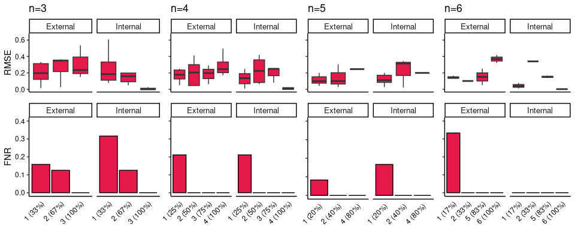

```r
num_row = 1
num_col = 4

num_cells = 3:6

g_list = list()
for (i in 1:length(num_cells)) {
  if (i %% num_col == 1) {
    this_show_y_title = T
    this_show_y_text = T
  } else {
    this_show_y_title = F
    this_show_y_text = F
  }

  this_cell_count = num_cells[i]
  g_list[[length(g_list)+1]] = onePlot(perform_raw_df %>% filter(total_nCell==this_cell_count),
                                       perform_median_df %>% filter(total_nCell==this_cell_count),
                                       'RMSE', paste('n=', this_cell_count, sep=''),
                                       show_x_text = F, show_y_title = this_show_y_title, keep_legend = F,
                                       ylims = list(c(0, 0.65), c(0, 0.4)), show_y_text = this_show_y_text)
}

ggpubr::ggarrange(plotlist=g_list, ncol=num_col, nrow=num_row, align='h', widths = c(1.2, 1, 1, 1))
```

### 4.4.2 RAE & FNR

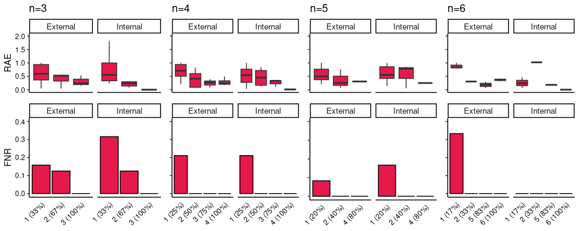

```r
if (save_file) {
  file_name = file.path(home.dir, 'Fig_STARmap_based_Oligo_performance.pdf')
  cairo_pdf(file_name, height=4, width=10, onefile=T)
  print(sprintf('figures saved in file %s', file_name))
}

num_row = 1
num_col = 4

num_cells = 3:6

g_list = list()
for (i in 1:length(num_cells)) {
  if (i %% num_col == 1) {
    this_show_y_title = T
    this_show_y_text = T
  } else {
    this_show_y_title = F
    this_show_y_text = F
  }

  this_cell_count = num_cells[i]
  g_list[[length(g_list)+1]] = onePlot(perform_raw_df %>% filter(total_nCell==this_cell_count),
                                       perform_median_df %>% filter(total_nCell==this_cell_count),
                                       'RAE', paste('n=', this_cell_count, sep=''),
                                       show_x_text = F, show_y_title = this_show_y_title, keep_legend = F,
                                       ylims = list(c(0, 2), c(0, 0.4)), show_y_text = this_show_y_text)
}

ggpubr::ggarrange(plotlist=g_list, ncol=num_col, nrow=num_row, align='h', widths = c(1.2, 1, 1, 1))
```

# 5 Performance by #Oligos in spot: High density sequencing-based simulation

## 5.1 Read estimated cell type proportions

```r
file_name = file.path(home.dir, 'simulation_seq_based_high_density_all_results.rds')
all_res_hq = readRDS(file_name)
print(sprintf('load data from %s', file_name))
```

```
[1] "load data from /home/hill103/Documents/Spatial/Figures/Simulation/simulation_seq_based_high_density_all_results.rds"
```

```r
stopifnot(all(row.names(all_res$Truth) == row.names(all_res_hq$Truth)))
stopifnot(all(colnames(all_res$Truth) == colnames(all_res_hq$Truth)))
stopifnot(all(all_res$Truth == all_res_hq$Truth))
```

Quality control.

```r
qc(all_res_hq)
```

## 5.2 Read recording of number of cells per spot

```r
file_name = file.path(home.dir, 'sim_seq_based_3x_spatial_spot_ncell.csv')
ncell_3x = read.csv(file_name, row.names = 1, check.names = F)
print(sprintf('load data from %s', file_name))
```

```
[1] "load data from /home/hill103/Documents/Spatial/Figures/Simulation/sim_seq_based_3x_spatial_spot_ncell.csv"
```

```r
stopifnot(all(row.names(ncell_3x) == row.names(all_res_hq$Truth)))
print(sprintf('3x setting: number of cells of all spots: min: %d; max: %d', min(ncell_3x$nCell), max(ncell_3x$nCell)))
```

```
[1] "3x setting: number of cells of all spots: min: 3; max: 27"
```

```r
# rename column
colnames(ncell_3x) = 'total_nCell'


file_name = file.path(home.dir, 'sim_seq_based_6x_spatial_spot_ncell.csv')
ncell_6x = read.csv(file_name, row.names = 1, check.names = F)
print(sprintf('load data from %s', file_name))
```

```
[1] "load data from /home/hill103/Documents/Spatial/Figures/Simulation/sim_seq_based_6x_spatial_spot_ncell.csv"
```

```r
stopifnot(all(row.names(ncell_6x) == row.names(all_res_hq$Truth)))
print(sprintf('6x setting: number of cells of all spots: min: %d; max: %d', min(ncell_6x$nCell), max(ncell_6x$nCell)))
```

```
[1] "6x setting: number of cells of all spots: min: 6; max: 54"
```

```r
# rename column
colnames(ncell_6x) = 'total_nCell'
```

Calculate number of Oligo cells in each spot.

```r
# note to round to nearest integer
nOligo_3x = round(ncell_3x * all_res_hq$Truth$Oligo)
nOligo_3x$total_nCell = as.integer(nOligo_3x$total_nCell)
# rename column
colnames(nOligo_3x) = 'nCell'
print('3x setting')
```

```
[1] "3x setting"
```

```r
table(nOligo_3x$nCell)
```

```
  0   3   6   9  12  15  18  21  24
435  80  35  14   9   2   3   2   1
```

```r
nOligo_6x = round(ncell_6x * all_res_hq$Truth$Oligo)
nOligo_6x$total_nCell = as.integer(nOligo_6x$total_nCell)
# rename column
colnames(nOligo_6x) = 'nCell'
print('6x setting')
```

```
[1] "6x setting"
```

```r
table(nOligo_6x$nCell)
```

```
  0   6  12  18  24  30  36  42  48
435  80  35  14   9   2   3   2   1
```

## 5.3 Evaluate performance of *Oligo*

```r
perform_raw_df = data.frame()
perform_median_df = data.frame()

for (x in c('1x', '3x', '6x')) {
  # subset results for only one density setting
  tmp_res = list()
  tmp_res$Truth = all_res_hq$Truth
  tmp_res$S1_int_ref = list()
  tmp_res$S1_int_ref$SDePER = all_res_hq$S1_int_ref[[paste('SDePER', x, sep='_')]]
  tmp_res$S1_ext_ref = list()
  tmp_res$S1_ext_ref$SDePER = all_res_hq$S1_ext_ref[[paste('SDePER', x, sep='_')]]

  if (x == '1x') {
    tmp_list = summaryPerform(calcPerformanceAllSpots(tmp_res), ncell_1x, nOligo_1x)
  } else if (x == '3x') {
    tmp_list = summaryPerform(calcPerformanceAllSpots(tmp_res), ncell_3x, nOligo_3x)
  } else if (x == '6x') {
    tmp_list = summaryPerform(calcPerformanceAllSpots(tmp_res), ncell_6x, nOligo_6x)
  }

  tmp_raw_df = tmp_list[[1]]
  tmp_raw_df$Dataset = x
  tmp_median_df = tmp_list[[2]]
  tmp_median_df$Dataset = x

  perform_raw_df = rbind(perform_raw_df, tmp_raw_df)
  perform_median_df = rbind(perform_median_df, tmp_median_df)
}

perform_median_df[, c('Dataset', 'Scenario', 'Method', 'Reference', 'total_nCell', 'nCell', 'median_RMSE', 'FDR', 'FNR')]
```

| Dataset | Scenario | Method | Reference | total_nCell | nCell | median_RMSE | FDR | FNR |
| --- | --- | --- | --- | --- | --- | --- | --- | --- |
| 1x | Scenario 1 | SDePER | Internal | 6 | 0 | 0.000 | 1 | NaN |
| 1x | Scenario 1 | SDePER | Internal | 6 | 2 | 0.155 | 0 | 0.000 |
| 1x | Scenario 1 | SDePER | Internal | 6 | 5 | 0.200 | 0 | 0.000 |
| 1x | Scenario 1 | SDePER | Internal | 6 | 6 | 0.323 | 0 | 0.000 |
| 1x | Scenario 1 | SDePER | Internal | 6 | 1 | 0.144 | 0 | 0.000 |
| 1x | Scenario 1 | SDePER | Internal | 2 | 0 | 0.000 | 1 | NaN |
| 1x | Scenario 1 | SDePER | Internal | 2 | 1 | 0.127 | 0 | 0.000 |
| 1x | Scenario 1 | SDePER | Internal | 2 | 2 | 0.028 | 0 | 0.000 |
| 1x | Scenario 1 | SDePER | Internal | 5 | 0 | 0.000 | 1 | NaN |
| 1x | Scenario 1 | SDePER | Internal | 5 | 1 | 0.118 | 0 | 0.167 |

[output cut: 194 more lines]

## 5.4 Draw figures

We included spots with total number of cells from 3 to 6 only, then stratified by number of Oligo cells in spots.

### 5.4.1 1x setting

#### 5.4.1.1 RMSE & FNR

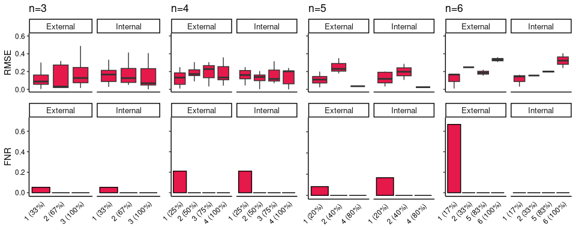

```r
num_row = 1
num_col = 4

num_cells = 3:6

g_list = list()
for (i in 1:length(num_cells)) {
  if (i %% num_col == 1) {
    this_show_y_title = T
    this_show_y_text = T
  } else {
    this_show_y_title = F
    this_show_y_text = F
  }

  this_cell_count = num_cells[i]
  g_list[[length(g_list)+1]] = onePlot(perform_raw_df %>% filter(Dataset == '1x' & total_nCell==this_cell_count),
                                       perform_median_df %>% filter(Dataset == '1x' & total_nCell==this_cell_count),
                                       'RMSE', paste('n=', this_cell_count, sep=''),
                                       show_x_text = F, show_y_title = this_show_y_title, keep_legend = F,
                                       ylims = list(c(0, 0.6), c(0, 0.7)), show_y_text = this_show_y_text)
}

ggpubr::ggarrange(plotlist=g_list, ncol=num_col, nrow=num_row, align='h', widths = c(1.2, 1, 1, 1))
```

#### 5.4.1.2 RAE & FNR

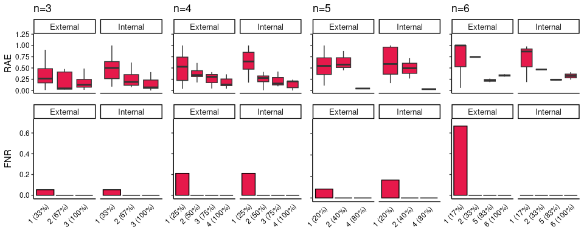

```r
num_row = 1
num_col = 4

num_cells = 3:6

g_list = list()
for (i in 1:length(num_cells)) {
  if (i %% num_col == 1) {
    this_show_y_title = T
    this_show_y_text = T
  } else {
    this_show_y_title = F
    this_show_y_text = F
  }

  this_cell_count = num_cells[i]
  g_list[[length(g_list)+1]] = onePlot(perform_raw_df %>% filter(Dataset == '1x' & total_nCell==this_cell_count),
                                       perform_median_df %>% filter(Dataset == '1x' & total_nCell==this_cell_count),
                                       'RAE', paste('n=', this_cell_count, sep=''),
                                       show_x_text = F, show_y_title = this_show_y_title, keep_legend = F,
                                       ylims = list(c(0, 1.2), c(0, 0.7)), show_y_text = this_show_y_text)
}

ggpubr::ggarrange(plotlist=g_list, ncol=num_col, nrow=num_row, align='h', widths = c(1.2, 1, 1, 1))
```

### 5.4.2 3x setting

#### 5.4.2.1 RMSE & FNR

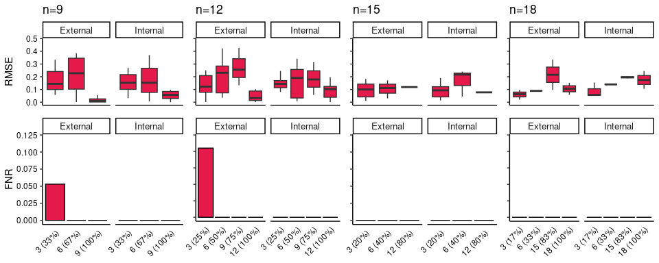

```r
num_row = 1
num_col = 4

num_cells = (3:6) * 3

g_list = list()
for (i in 1:length(num_cells)) {
  if (i %% num_col == 1) {
    this_show_y_title = T
    this_show_y_text = T
  } else {
    this_show_y_title = F
    this_show_y_text = F
  }

  this_cell_count = num_cells[i]
  g_list[[length(g_list)+1]] = onePlot(perform_raw_df %>% filter(Dataset == '3x' & total_nCell==this_cell_count),
                                       perform_median_df %>% filter(Dataset == '3x' & total_nCell==this_cell_count),
                                       'RMSE', paste('n=', this_cell_count, sep=''),
                                       show_x_text = F, show_y_title = this_show_y_title, keep_legend = F,
                                       ylims = list(c(0, 0.48), c(0, 0.12)), show_y_text = this_show_y_text)
}

ggpubr::ggarrange(plotlist=g_list, ncol=num_col, nrow=num_row, align='h', widths = c(1.2, 1, 1, 1))
```

#### 5.4.2.2 RAE & FNR

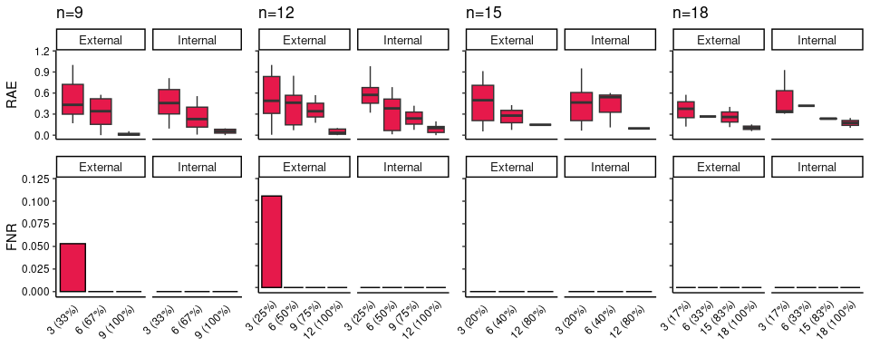

```r
num_row = 1
num_col = 4

num_cells = (3:6) * 3

g_list = list()
for (i in 1:length(num_cells)) {
  if (i %% num_col == 1) {
    this_show_y_title = T
    this_show_y_text = T
  } else {
    this_show_y_title = F
    this_show_y_text = F
  }

  this_cell_count = num_cells[i]
  g_list[[length(g_list)+1]] = onePlot(perform_raw_df %>% filter(Dataset == '3x' & total_nCell==this_cell_count),
                                       perform_median_df %>% filter(Dataset == '3x' & total_nCell==this_cell_count),
                                       'RAE', paste('n=', this_cell_count, sep=''),
                                       show_x_text = F, show_y_title = this_show_y_title, keep_legend = F,
                                       ylims = list(c(0, 1.15), c(0, 0.12)), show_y_text = this_show_y_text)
}

ggpubr::ggarrange(plotlist=g_list, ncol=num_col, nrow=num_row, align='h', widths = c(1.2, 1, 1, 1))
```

### 5.4.3 6x setting

#### 5.4.3.1 RMSE & FNR

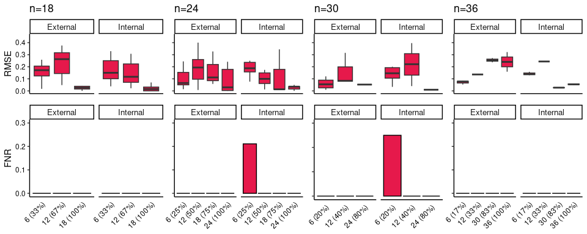

```r
num_row = 1
num_col = 4

num_cells = (3:6) * 6

g_list = list()
for (i in 1:length(num_cells)) {
  if (i %% num_col == 1) {
    this_show_y_title = T
    this_show_y_text = T
  } else {
    this_show_y_title = F
    this_show_y_text = F
  }

  this_cell_count = num_cells[i]
  g_list[[length(g_list)+1]] = onePlot(perform_raw_df %>% filter(Dataset == '6x' & total_nCell==this_cell_count),
                                       perform_median_df %>% filter(Dataset == '6x' & total_nCell==this_cell_count),
                                       'RMSE', paste('n=', this_cell_count, sep=''),
                                       show_x_text = F, show_y_title = this_show_y_title, keep_legend = F,
                                       ylims = list(c(0, 0.45), c(0, 0.3)), show_y_text = this_show_y_text)
}

ggpubr::ggarrange(plotlist=g_list, ncol=num_col, nrow=num_row, align='h', widths = c(1.2, 1, 1, 1))
```

#### 5.4.3.2 RAE & FNR

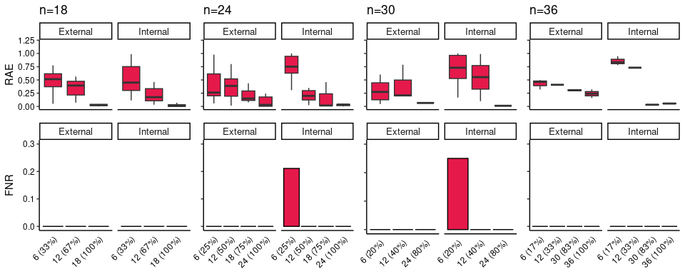

```r
num_row = 1
num_col = 4

num_cells = (3:6) * 6

g_list = list()
for (i in 1:length(num_cells)) {
  if (i %% num_col == 1) {
    this_show_y_title = T
    this_show_y_text = T
  } else {
    this_show_y_title = F
    this_show_y_text = F
  }

  this_cell_count = num_cells[i]
  g_list[[length(g_list)+1]] = onePlot(perform_raw_df %>% filter(Dataset == '6x' & total_nCell==this_cell_count),
                                       perform_median_df %>% filter(Dataset == '6x' & total_nCell==this_cell_count),
                                       'RAE', paste('n=', this_cell_count, sep=''),
                                       show_x_text = F, show_y_title = this_show_y_title, keep_legend = F,
                                       ylims = list(c(0, 1.2), c(0, 0.3)), show_y_text = this_show_y_text)
}

ggpubr::ggarrange(plotlist=g_list, ncol=num_col, nrow=num_row, align='h', widths = c(1.2, 1, 1, 1))
```

# 6 Performance by #Oligos in downsampled ref: STARmap-based simulation

## 6.1 Read estimated cell type proportions

```r
file_name = file.path(home.dir, 'simulation_downsampled_ref_all_results.rds')
all_res_tmp = readRDS(file_name)
print(sprintf('load data from %s', file_name))
```

```
[1] "load data from /home/hill103/Documents/Spatial/Figures/Simulation/simulation_downsampled_ref_all_results.rds"
```

```r
all_res_ds = list()
all_res_ds$Truth = all_res_tmp$Truth
all_res_ds$S1_int_ref = all_res_tmp$Oligo$S1_int_ref
all_res_ds$S1_ext_ref = all_res_tmp$Oligo$S1_ext_ref

stopifnot(all(row.names(all_res$Truth) == row.names(all_res_ds$Truth)))
stopifnot(all(colnames(all_res$Truth) == colnames(all_res_ds$Truth)))
stopifnot(all(all_res$Truth == all_res_ds$Truth))

rm(all_res_tmp)
```

Quality control.

```r
qc(all_res_ds)
```

## 6.2 Evaluate performance of *Oligo*

```r
tmp_list = summaryPerformDSRef(calcPerformanceAllSpots(all_res_ds))
perform_raw_df = tmp_list[[1]]
perform_median_df = tmp_list[[2]]

perform_median_df[, c('Scenario', 'Method', 'Reference', 'nCell', 'median_RMSE', 'FDR', 'FNR')]
```

|  | Scenario | Method | Reference | nCell | median_RMSE | FDR | FNR |
| --- | --- | --- | --- | --- | --- | --- | --- |
| 1 | Scenario 1 | SDePER | Internal | 5 | 0.000 | 0.487 | 0.048 |
| 2 | Scenario 1 | GLRM | Internal | 5 | 0.000 | 0.203 | 0.034 |
| 3 | Scenario 1 | SDePER | Internal | 10 | 0.028 | 0.565 | 0.034 |
| 4 | Scenario 1 | GLRM | Internal | 10 | 0.000 | 0.263 | 0.021 |
| 5 | Scenario 1 | SDePER | Internal | 20 | 0.000 | 0.357 | 0.089 |
| 6 | Scenario 1 | GLRM | Internal | 20 | 0.000 | 0.269 | 0.014 |
| 7 | Scenario 1 | SDePER | Internal | 50 | 0.000 | 0.195 | 0.123 |
| 8 | Scenario 1 | GLRM | Internal | 50 | 0.000 | 0.321 | 0.014 |
| 9 | Scenario 1 | SDePER | Internal | all | 0.000 | 0.254 | 0.116 |
| 10 | Scenario 1 | GLRM | Internal | all | 0.000 | 0.335 | 0.007 |

[output cut: 10 more lines]

## 6.3 Draw figures

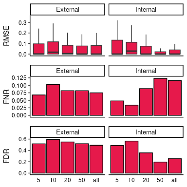

```r
if (save_file) {
  file_name = file.path(home.dir, 'Fig_STARmap_based_downsample_ref_Oligo_performance.pdf')
  cairo_pdf(file_name, height=4, width=4, onefile=T)
  print(sprintf('figures saved in file %s', file_name))
}

plot_df = perform_raw_df %>%
  filter(Method == 'SDePER')
plot_df$nCell = factor(plot_df$nCell, levels = c("5", "10", "20", "50", "all"))

plot_median_df = perform_median_df %>%
  filter(Method == 'SDePER')
plot_median_df$nCell = factor(plot_median_df$nCell, levels = c("5", "10", "20", "50", "all"))

onePlotDS(plot_df, plot_median_df, show_x_text = F, keep_legend = F, ylims = list(c(0, 0.35), NULL, NULL))
```